# problem6_english

problem6. Add different levels of Gaussian noises to a given image, observe the  
change of corresponding histograms (based on the program you  
developed above). And then process the Gaussian noise polluted  
images using your designed kernels to achieve desired effect. (Both  
code and result report are required.)

This time, let's take a quick look at noise and filters.  
Noise is a major cause of poor image quality.

Anyway, let's take a quick look at Gaussian noise.

[figure not shown]

lenna(added gaussian noise)  
It is called Gaussian noise because it follows a Gaussian distribution.

[figure not shown]

Gaussian noise usually occurs in the process of compression, transmission, etc. of an image.  
As the image is compressed, the image is reduced, and in the subsequent recovery process,  
a value with errors may be included, not the original pixel value, due to various causes.  
The noise that occurs is Gaussian noise.

Even when an image is transferred, it is compressed and then transferred. Although there is nothing wrong with the process of compression and restoration,  
a Gaussian noise can be generated if an error occurs during the transmission.

```python
import cv2
import matplotlib.pyplot as plt
import numpy as np
import warnings
warnings.filterwarnings(action='ignore')
```

[figure not shown]

```python
#img = cv2.imread('./Lenna.png')
#img =cv2.cvtColor(img,cv2.COLOR_BGR2RGB)
img = cv2.imread('./Lenna.png')
img =cv2.cvtColor(img,cv2.COLOR_BGR2RGB)
gray = cv2.cvtColor(img, cv2.COLOR_RGB2GRAY)
noise = np.zeros(gray.shape)

def make_noise(std, gray):
    height, width = gray.shape
    img_noise = np.zeros((height, width), dtype=np.float)
    for i in range(height):
        for a in range(width):
            make_noise = np.random.normal()  # 랜덤함수를 이용하여 노이즈 적용
            set_noise = std * make_noise
            noise[i][a] += set_noise
            img_noise[i][a] = gray[i][a] + set_noise
    return img_noise
std=10
img_noise = make_noise(std, gray)


fig = plt.figure(figsize=(20,8))
plt.subplot(1,4,1)
plt.imshow(img)
plt.subplot(1,4,2)
plt.imshow(gray,cmap='gray')
plt.subplot(1,4,3)
plt.imshow(img_noise,cmap='gray')
plt.show()
```

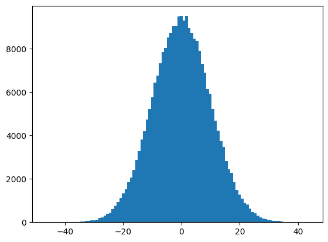

```python
gray_flat = gray.flatten()
noise_flat= img_noise.flatten()
gaussian_noise_flat = noise.flatten()
plt.hist(gaussian_noise_flat,bins=100)
#plt.hist(noise_flat,bins=100)
```

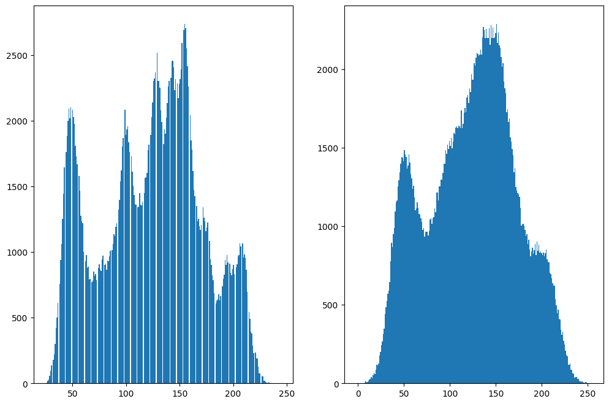

```python
def get_histogram(img, bins = 100):#100개 구간으로 슬라이싱한 히스토그램 데이터입니다., density=True
    min_data = np.min(img)
    max_data = np.max(img)

    dx = (max_data - min_data) / bins #bins가 한번 돌아갈때마다 x축을 그리는 구간이 dx입니다.
    x = np.zeros(bins)
    y = np.zeros(bins+1)#for문이 0~bin까지 돌기 때문에 y 배열은 x배열보다 1 커야합니다.
    for i in range(bins):
        x[i] = i*dx + min_data
    #print(img.size)
    for j in img:
        #print(j)
        bin = int((j - min_data) / dx)
        #print(y)
        y[bin] += 1

    y[bins-2] += y[bins-1]
    y = y[:bins]

    plt.bar(x, y, width=dx)
    return np.column_stack((x, y))
plt.figure(figsize=(12,8))
plt.subplot(1,2,1)
hist =get_histogram(gray_flat,256)
plt.subplot(1,2,2)
hist2 = get_histogram(noise_flat, 256)

# plt.subplot(1,2,1)
# plt.plot(hist)
# plt.subplot(1,2,2)
# plt.plot(hist2)
```

finally, scailing noised image

[figure not shown]

```python
def scailing():
    #gray
    # img = cv2.imread('./Lenna.png')
    # plt.imshow([img])

    gray = cv2.cvtColor(img, cv2.COLOR_BGR2GRAY)
    height, width = gray.shape

    std = 10
    img_noise = make_noise(std, gray)
    img_noise2 = make_noise(std, gray)
    img_noise3 = make_noise(std, gray)
    img_noise4 = make_noise(std, gray)

    out2 = np.zeros((height, width), dtype=np.float)
    out3 = np.zeros((height, width), dtype=np.float)
    out4 = np.zeros((height, width), dtype=np.float)
    # 평균 계산
    for i in range(height):
        for j in range(width):
            if (img_noise[i][j] + img_noise2[i][j]) / 2 > 255:
                out2[i][j] = 255
            else:
                out2[i][j] = (img_noise[i][j] + img_noise2[i][j]) / 2

            if (img_noise[i][j] + img_noise2[i][j] + img_noise3[i][j]) / 3 > 255:
                out3[i][j] = 255
            else:
                out3[i][j] = (img_noise[i][j] + img_noise2[i][j] + img_noise3[i][j]) / 3

            if (img_noise[i][j] + img_noise2[i][j] + img_noise3[i][j] + img_noise4[i][j]) / 4 > 255:
                out4[i][j] = 255
            else:
                out4[i][j] = (img_noise[i][j] + img_noise2[i][j] + img_noise3[i][j] + img_noise4[i][j]) / 4

    plt.figure(figsize=(20,12))
    plt.subplot(1,4,1)
    plt.imshow(gray,cmap='gray')
    plt.subplot(1,4,2)
    plt.imshow(out2,cmap='gray')
    plt.subplot(1,4,3)
    plt.imshow(out3,cmap='gray')
    plt.subplot(1,4,4)
    plt.imshow(out4,cmap='gray')



scailing()
```